# Estatística Multivariada

2ª Lista de Exercícios

Elton Dantas de Oliveira Mesquita

## Questão 1 - Objetivos da ACP

O objetivo da Análise de Componentes Principais é explicar a estrutura de variância e covariância de um vetor aleatório, composto de p variáveis aleatórias, através de combinações lineares das variáveis originais. Em geral, pode-se dizer também que o objetivo da ACP é obter redução do número de variáveis a serem avaliadas e interpretar as combinações lineares construídas.

## Questão 2 - Componentes Principais

Componentes principais são combinações lineares (não correlacionadas) de p variáveis aleatórias originais de um vetor aleatório.

## Questão 3 - Autovalores e Autovetores

Em ACP, os autovalores representam as variâncias das componentes principais e os autovetores, os coeficientes de cada uma dessas componentes.

## Questão 4 - Padronização das Variáveis

As componentes principais obtidas através da matriz de covariâncias são influenciadas pelas variáveis de maior variância, sendo, portanto, de pouca utilidade nos casos em que existe uma discrepância muito acentuada entre as variâncias. A discrepância é muitas vezes causada pela diferença das unidades de medidas (escalas) das variáveis. Este problema pode ser amenizado se uma transformação for efetuada nos dados originais, de modo a quilibrar os valores de variância ou colocar os dados na mesma escala de medida. Uma das transformações mais comuns é aquela em que cada variável é padronizada pela sua média e desvio padrão, sendo a ACP aplicada à matriz de covariâncias das variáveis padronizadas. Este procedimento equivale a obter-se as componentes principais através da matriz de correlação das variáveis originais.

## Questão 5 - Escores de uma CP

Em termos práticos, para se fazer uso das componentes principais amostrais consideradas mais relevantes na análise de dados, é necessário calcular os seus valores numéricos para cada elemento amostral. Esses valores são os escores das componentes.

## Questão 6

Autovalores

```r
cps = c("CP1","CP2","CP3","CP4","CP5","CP6","CP7")

autoval = matrix(c(4.58,1.51,0.39,0.36,0.12,0.03,0.01),byrow=T,nrow=1)

colnames(autoval) = cps

autoval
```

```
##       CP1  CP2  CP3  CP4  CP5  CP6  CP7
## [1,] 4.58 1.51 0.39 0.36 0.12 0.03 0.01
```

Autovetores

```r
variaveis = c("Calorias","Carboidratos","Gorduras","Gordura Saturada",
              "Gordura Trans","Proteínas", "Sódio")

autovet = matrix(c(-0.45,0.14,-0.08,-0.26,0.09,-0.22,0.8,
                   -0.14,0.74,-0.24,-0.4,-0.32,0.22,-0.26,
                   -0.46,-0.03,0.08,-0.19,0.28,-0.64,-0.51,
                   -0.41,-0.32,0.08,-0.33,0.37,0.68,-0.13,
                   -0.41,-0.26,0.41,0.06,-0.77,0.03,-0.02,
                   -0.38,-0.16,-0.77,0.47,-0.12,0.06,-0.08,
                   -0.3,0.49,0.4,0.64,0.27,0.17,0),
                 byrow = T, nrow = 7)

rownames(autovet) = variaveis
colnames(autovet) = cps

autovet
```

```
##                    CP1   CP2   CP3   CP4   CP5   CP6   CP7
## Calorias         -0.45  0.14 -0.08 -0.26  0.09 -0.22  0.80
## Carboidratos     -0.14  0.74 -0.24 -0.40 -0.32  0.22 -0.26
## Gorduras         -0.46 -0.03  0.08 -0.19  0.28 -0.64 -0.51
## Gordura Saturada -0.41 -0.32  0.08 -0.33  0.37  0.68 -0.13
## Gordura Trans    -0.41 -0.26  0.41  0.06 -0.77  0.03 -0.02
## Proteínas        -0.38 -0.16 -0.77  0.47 -0.12  0.06 -0.08
## Sódio            -0.30  0.49  0.40  0.64  0.27  0.17  0.00
```

### a)

Porcentagem de variação de cada componente principal.

```r
perc = autoval/sum(autoval) * 100
perc
```

```
##           CP1      CP2      CP3      CP4      CP5       CP6       CP7
## [1,] 65.42857 21.57143 5.571429 5.142857 1.714286 0.4285714 0.1428571
```

Porcentagens de variação acumuladas das componentes

```r
perc_acum = cumsum(perc)
perc_acum
```

```
## [1]  65.42857  87.00000  92.57143  97.71429  99.42857  99.85714 100.00000
```

### b)

A importância das CP pode ser visualizada usando o screeplot

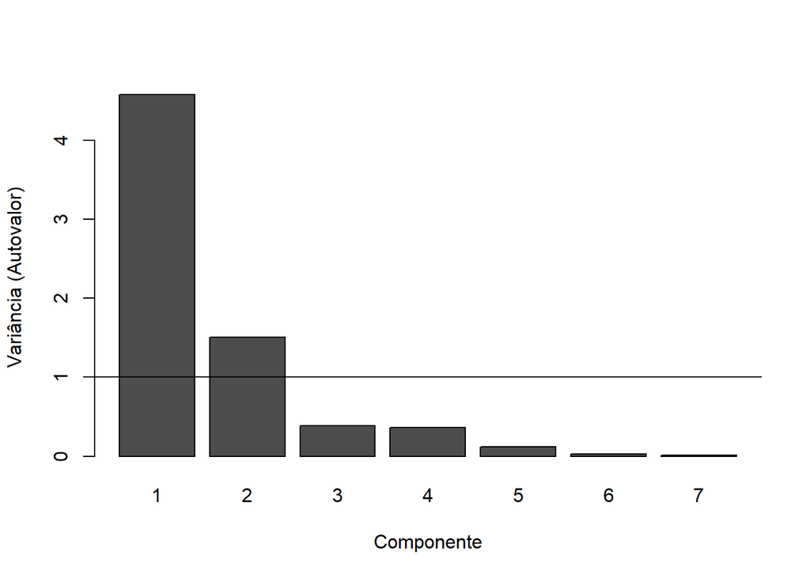

```r
plot = barplot(autoval, names.arg = 1:length(autoval),
        xlab = "Componente", ylab = "Variância (Autovalor)") + abline(h=1)
```

As duas primeiras componentes principais representam 87% da variação total das variáveis originais. Além disso, baseando-se no critério de Kaiser, temos que os autovalores associados às demais componentes são menores que 1. Então, considerando esses fatores, podemos dizer que as duas primeiras componentes são suficientes.

## Questão 7

Matriz de covariâncias

```r
S = matrix(c(5,2,
             2,2), byrow=T, nrow=2)
S
```

```
##      [,1] [,2]
## [1,]    5    2
## [2,]    2    2
```

### a)

Componentes Principais para a matriz de covariâncias

```r
X = c("X1","X2")
cps = c("Y1","Y2")

# Encontrando os autovalores e autovetores
auto = eigen(S)
autoval = matrix(auto$values,nrow=1)
colnames(autoval) = cps
autovet = auto$vectors
colnames(autovet) = cps
rownames(autovet) = X

autoval
```

```
##      Y1 Y2
## [1,]  6  1
```

```r
round(autovet,2)
```

```
##       Y1    Y2
## X1 -0.89  0.45
## X2 -0.45 -0.89
```

$Y_2 = 0.45X_1 - 0.89X_2$

Proporção da variância total explicada pelas componentes principais

```r
perc = autoval/sum(autoval)*100
perc
```

```
##            Y1       Y2
## [1,] 85.71429 14.28571
```

Percebe-se que, pela sua proporção de variância total, a primeira componente principal representa quase 86% da variância total das variáveis originais.

### b)

Matriz de correlação P

```r
# Encontrando a matriz V^(1/2)
sqrtV = diag(sqrt(diag(S)))

# Encontrando a matriz P
sqrtV.inv = solve(sqrtV)
P = sqrtV.inv %*% S %*% sqrtV.inv
P
```

```
##           [,1]      [,2]
## [1,] 1.0000000 0.6324555
## [2,] 0.6324555 1.0000000
```

Componentes principais da matriz de correlações P

```r
# Encontrando os autovalores e autovetores
auto = eigen(P)
autoval = matrix(auto$values,nrow=1)
colnames(autoval) = cps
autovet = auto$vectors
colnames(autovet) = cps
rownames(autovet) = X

autoval
```

```
##            Y1        Y2
## [1,] 1.632456 0.3675445
```

```r
round(autovet,2)
```

```
##       Y1    Y2
## X1 -0.71  0.71
## X2 -0.71 -0.71
```

$Y_1 = -0.71X_1 - 0.71X_2$

$Y_2 = 0.71X_1 - 0.71X_2$

Proporção da variância total explicadas pelas componentes principais

```r
perc = autoval/sum(autoval)*100
perc
```

```
##            Y1       Y2
## [1,] 81.62278 18.37722
```

### Questão 8

Em anexo, feita à mão.

## Questão 9

Pacotes e Dados

```r
library(FactoMineR)
library(factoextra)
library(psych)
```

```r
library(ggcorrplot)
library(dplyr)
data(decathlon)
dim(decathlon)
```

```
## [1] 41 13
```

```r
dados = decathlon[1:10]
```

### a) Breve análise exploratória dos dados

Algumas medidas resumo

```r
describe(dados)
```

```
##             vars  n   mean    sd median trimmed   mad    min    max range  skew
## 100m           1 41  11.00  0.26  10.98   11.00  0.22  10.44  11.64  1.20  0.05
## Long.jump      2 41   7.26  0.32   7.30    7.25  0.34   6.61   7.96  1.35  0.05
## Shot.put       3 41  14.48  0.82  14.57   14.47  0.83  12.68  16.36  3.68 -0.04
## High.jump      4 41   1.98  0.09   1.95    1.97  0.10   1.85   2.15  0.30  0.31
## 400m           5 41  49.62  1.15  49.40   49.56  0.99  46.81  53.20  6.39  0.59
## 110m.hurdle    6 41  14.61  0.47  14.48   14.58  0.59  13.97  15.67  1.70  0.36
## Discus         7 41  44.33  3.38  44.41   44.19  3.50  37.92  51.65 13.73  0.29
## Pole.vault     8 41   4.76  0.28   4.80    4.75  0.30   4.20   5.40  1.20  0.22
## Javeline       9 41  58.32  4.83  58.36   58.07  4.43  50.31  70.52 20.21  0.46
## 1500m         10 41 279.02 11.67 278.05  277.95 10.45 262.10 317.00 54.90  0.95
##             kurtosis   se
## 100m           -0.33 0.04
## Long.jump      -0.53 0.05
## Shot.put       -0.52 0.13
## High.jump      -1.07 0.01
## 400m            0.99 0.18
## 110m.hurdle    -1.13 0.07
## Discus         -0.79 0.53
## Pole.vault     -0.54 0.04
## Javeline       -0.20 0.75
## 1500m           1.05 1.82
```

Matriz de correlação

```r
# Correlation matrix
matcor = round(cor(dados), 2)
matcor
```

```
##              100m Long.jump Shot.put High.jump  400m 110m.hurdle Discus
## 100m         1.00     -0.60    -0.36     -0.25  0.52        0.58  -0.22
## Long.jump   -0.60      1.00     0.18      0.29 -0.60       -0.51   0.19
## Shot.put    -0.36      0.18     1.00      0.49 -0.14       -0.25   0.62
## High.jump   -0.25      0.29     0.49      1.00 -0.19       -0.28   0.37
## 400m         0.52     -0.60    -0.14     -0.19  1.00        0.55  -0.12
## 110m.hurdle  0.58     -0.51    -0.25     -0.28  0.55        1.00  -0.33
## Discus      -0.22      0.19     0.62      0.37 -0.12       -0.33   1.00
## Pole.vault  -0.08      0.20     0.06     -0.16 -0.08        0.00  -0.15
## Javeline    -0.16      0.12     0.37      0.17  0.00        0.01   0.16
## 1500m       -0.06     -0.03     0.12     -0.04  0.41        0.04   0.26
##             Pole.vault Javeline 1500m
## 100m             -0.08    -0.16 -0.06
## Long.jump         0.20     0.12 -0.03
## Shot.put          0.06     0.37  0.12
## High.jump        -0.16     0.17 -0.04
## 400m             -0.08     0.00  0.41
## 110m.hurdle       0.00     0.01  0.04
## Discus           -0.15     0.16  0.26
## Pole.vault        1.00    -0.03  0.25
## Javeline         -0.03     1.00 -0.18
## 1500m             0.25    -0.18  1.00
```

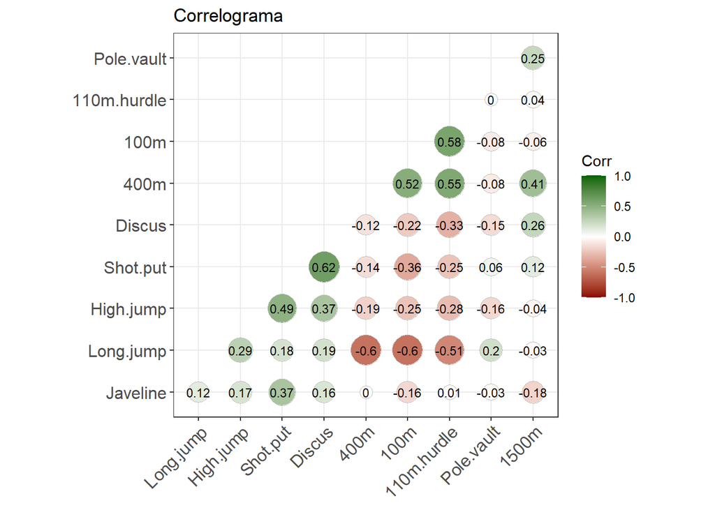

```r
# Plot
ggcorrplot(matcor, hc.order = TRUE,
           type = "lower",
           lab = TRUE,
           lab_size = 3,
           method="circle",
           colors = c("darkred", "white", "darkgreen"),
           title="Correlograma",
           ggtheme=theme_bw)
```

Box-plot dos dados

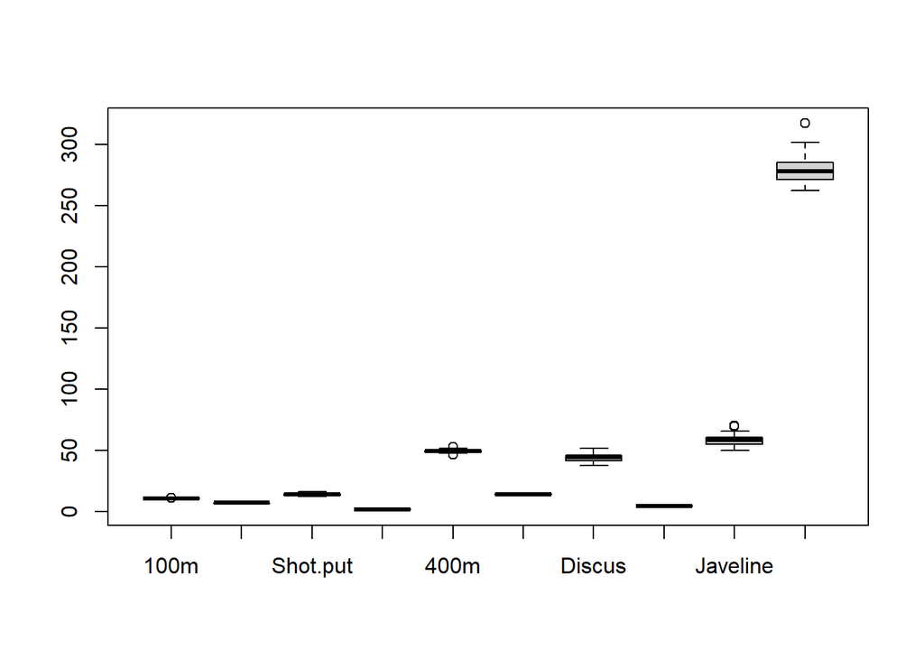

```r
# Dos dados originais
boxplot(dados)
```

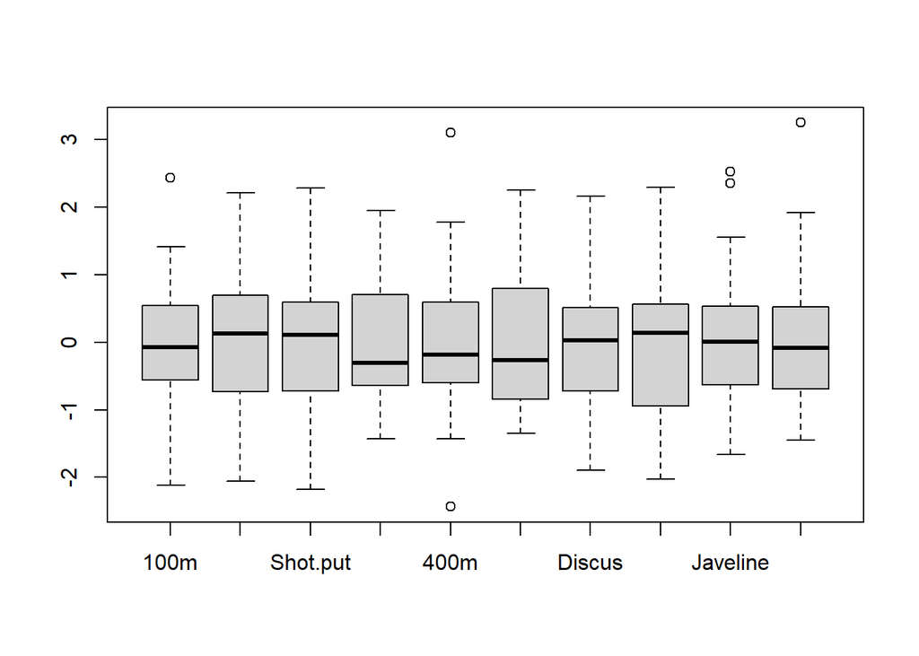

```r
# Dos dados padronizados
boxplot(scale(dados))
```

Pelas medidas-resumo obtidas e a visualização dos box-plots dos dados originais, percebe-se que as variáveis estão medidas em unidades diferentes e em escalas também diferentes de acordo com o tipo de prova. Sendo assim, será necessário padronizarmos os dados trabalhando com a matriz de correlações ao invés da matriz de covariâncias.

### b) Análise de Componentes Principais

```r
pca = PCA(dados,scale.unit = T,graph = F)
pca
```

```
## **Results for the Principal Component Analysis (PCA)**
## The analysis was performed on 41 individuals, described by 10 variables
## *The results are available in the following objects:
##
##    name               description
## 1  "$eig"             "eigenvalues"
## 2  "$var"             "results for the variables"
## 3  "$var$coord"       "coord. for the variables"
## 4  "$var$cor"         "correlations variables - dimensions"
## 5  "$var$cos2"        "cos2 for the variables"
## 6  "$var$contrib"     "contributions of the variables"
## 7  "$ind"             "results for the individuals"
## 8  "$ind$coord"       "coord. for the individuals"
## 9  "$ind$cos2"        "cos2 for the individuals"
## 10 "$ind$contrib"     "contributions of the individuals"
## 11 "$call"            "summary statistics"
## 12 "$call$centre"     "mean of the variables"
## 13 "$call$ecart.type" "standard error of the variables"
## 14 "$call$row.w"      "weights for the individuals"
## 15 "$call$col.w"      "weights for the variables"
```

```r
summary(pca, ncp = 10)
```

```
##
## Call:
## PCA(X = dados, scale.unit = T, graph = F)
##
##
## Eigenvalues
##                        Dim.1   Dim.2   Dim.3   Dim.4   Dim.5   Dim.6   Dim.7
## Variance               3.272   1.737   1.405   1.057   0.685   0.599   0.451
## % of var.             32.719  17.371  14.049  10.569   6.848   5.993   4.512
## Cumulative % of var.  32.719  50.090  64.140  74.708  81.556  87.548  92.061
##                        Dim.8   Dim.9  Dim.10
## Variance               0.397   0.215   0.182
## % of var.              3.969   2.148   1.822
## Cumulative % of var.  96.030  98.178 100.000
##
## Individuals (the 10 first)
##                 Dist    Dim.1    ctr   cos2    Dim.2    ctr   cos2    Dim.3
## SEBRLE      |  2.369 |  0.792  0.467  0.112 |  0.772  0.836  0.106 |  0.827
## CLAY        |  3.507 |  1.235  1.137  0.124 |  0.575  0.464  0.027 |  2.141
## KARPOV      |  3.396 |  1.358  1.375  0.160 |  0.484  0.329  0.020 |  1.956
## BERNARD     |  2.763 | -0.610  0.277  0.049 | -0.875  1.074  0.100 |  0.890
## YURKOV      |  3.018 | -0.586  0.256  0.038 |  2.131  6.376  0.499 | -1.225
## WARNERS     |  2.428 |  0.357  0.095  0.022 | -1.685  3.986  0.482 |  0.767
## ZSIVOCZKY   |  2.563 |  0.272  0.055  0.011 | -1.094  1.680  0.182 | -1.283
## McMULLEN    |  2.561 |  0.588  0.257  0.053 |  0.231  0.075  0.008 | -0.418
## MARTINEAU   |  3.742 | -1.995  2.968  0.284 |  0.561  0.442  0.022 | -0.730
## HERNU       |  2.794 | -1.546  1.782  0.306 |  0.488  0.335  0.031 |  0.841
##                ctr   cos2    Dim.4    ctr   cos2    Dim.5    ctr   cos2
## SEBRLE       1.187  0.122 |  1.175  3.184  0.246 |  0.707  1.781  0.089 |
## CLAY         7.960  0.373 | -0.355  0.291  0.010 | -1.975 13.887  0.317 |
## KARPOV       6.644  0.332 | -1.857  7.954  0.299 |  0.795  2.252  0.055 |
## BERNARD      1.375  0.104 |  2.221 11.380  0.646 |  0.362  0.466  0.017 |
## YURKOV       2.606  0.165 |  0.874  1.761  0.084 |  1.251  5.578  0.172 |
## WARNERS      1.020  0.100 | -0.589  0.801  0.059 |  1.002  3.574  0.170 |
## ZSIVOCZKY    2.857  0.250 | -1.622  6.068  0.400 |  0.044  0.007  0.000 |
## McMULLEN     0.303  0.027 | -1.524  5.362  0.354 |  0.252  0.225  0.010 |
## MARTINEAU    0.925  0.038 | -0.542  0.678  0.021 |  1.578  8.872  0.178 |
## HERNU        1.227  0.091 |  0.331  0.253  0.014 | -0.235  0.197  0.007 |
##
## Variables
##                Dim.1    ctr   cos2    Dim.2    ctr   cos2    Dim.3    ctr
## 100m        | -0.775 18.344  0.600 |  0.187  2.016  0.035 | -0.184  2.420
## Long.jump   |  0.742 16.822  0.550 | -0.345  6.869  0.119 |  0.182  2.363
## Shot.put    |  0.623 11.844  0.388 |  0.598 20.607  0.358 | -0.023  0.039
## High.jump   |  0.572  9.998  0.327 |  0.350  7.064  0.123 | -0.260  4.794
## 400m        | -0.680 14.116  0.462 |  0.569 18.666  0.324 |  0.131  1.230
## 110m.hurdle | -0.746 17.020  0.557 |  0.229  3.013  0.052 | -0.093  0.611
## Discus      |  0.552  9.328  0.305 |  0.606 21.162  0.368 |  0.043  0.131
## Pole.vault  |  0.050  0.077  0.003 | -0.180  1.873  0.033 |  0.692 34.061
## Javeline    |  0.277  2.347  0.077 |  0.317  5.784  0.100 | -0.390 10.807
## 1500m       | -0.058  0.103  0.003 |  0.474 12.946  0.225 |  0.782 43.543
##               cos2    Dim.4    ctr   cos2    Dim.5    ctr   cos2
## 100m         0.034 | -0.038  0.135  0.001 |  0.302 13.336  0.091 |
## Long.jump    0.033 |  0.102  0.980  0.010 |  0.037  0.196  0.001 |
## Shot.put     0.001 |  0.191  3.437  0.036 |  0.111  1.804  0.012 |
## High.jump    0.067 | -0.136  1.740  0.018 |  0.555 45.053  0.309 |
## 400m         0.017 |  0.029  0.081  0.001 | -0.088  1.123  0.008 |
## 110m.hurdle  0.009 |  0.291  8.003  0.085 |  0.164  3.943  0.027 |
## Discus       0.002 | -0.260  6.380  0.067 | -0.105  1.605  0.011 |
## Pole.vault   0.479 |  0.552 28.783  0.304 |  0.330 15.899  0.109 |
## Javeline     0.152 |  0.712 48.005  0.507 | -0.305 13.596  0.093 |
## 1500m        0.612 | -0.161  2.455  0.026 | -0.154  3.444  0.024 |
```

A importância dos CP pode ser visualizada usando o screeplot

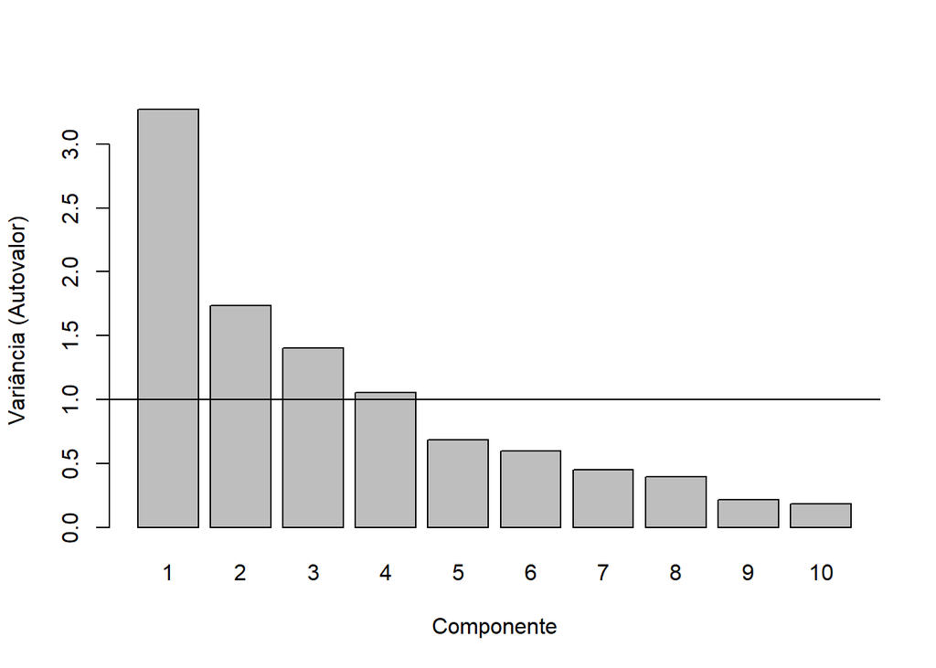

```r
plot = barplot(pca$svd$vs^2, names.arg = 1:length(dados),
        xlab = "Componente", ylab = "Variância (Autovalor)") + abline(h=1)
```

As quatro primeiras componentes principais representam quase 75% da variação total das variáveis originais. Além disso, baseando-se no critério de Kaiser, temos que os autovalores associados às demais componentes são menores que 1. Então, considerando esses fatores, selecionamos as quatro componentes principais.

### c) Ranking dos atletas

Ranking proposto a partir da primeira componente principal.

```r
score = facto_summarize(pca, "ind")
ranking = score %>% arrange(desc(score$Dim.1))
ranking
```

```
##                    name        Dim.1       Dim.2       coord        cos2
## Karpov           Karpov  4.619987275  0.03999523 21.34588204 0.851819129
## Sebrle           Sebrle  4.038448501  1.36582606 18.17454713 0.774953352
## Clay               Clay  3.919365157  0.83696136 16.06192756 0.743637228
## Macey             Macey  2.233460566  1.04176620  6.07362291 0.515088139
## Warners         Warners  2.168396445 -1.80320025  7.95347429 0.896415275
## Bernard         Bernard  1.906334368 -0.08580429  3.64147310 0.455557640
## KARPOV           KARPOV  1.358214936  0.48402090  2.07902404 0.180227971
## CLAY               CLAY  1.234990563  0.57457807  1.85534164 0.150852069
## Zsivoczky     Zsivoczky  0.925132183  1.16865180  2.22161658 0.337441123
## Hernu             Hernu  0.889037852 -0.61842522  1.17283805 0.352440199
## Smith             Smith  0.870310570  1.05932552  1.87961105 0.150301003
## SEBRLE           SEBRLE  0.791627717  0.77161120  1.22205828 0.217781505
## McMULLEN       McMULLEN  0.587516189  0.23072991  0.39841156 0.060730354
## Pogorelov     Pogorelov  0.539677028  0.77075099  0.88530838 0.155914905
## Ojaniemi       Ojaniemi  0.380113999 -0.77244734  0.74116155 0.135638967
## WARNERS         WARNERS  0.356889530 -1.68495667  2.96644910 0.503251291
## Averyanov     Averyanov  0.349155138 -1.55864999  2.55129911 0.401518959
## Nool               Nool  0.295305667 -1.54561667  2.47613633 0.257980427
## ZSIVOCZKY     ZSIVOCZKY  0.271774781 -1.09377558  1.27020655 0.193345423
## Schoenbeck   Schoenbeck  0.114430985 -0.03985061  0.01468252 0.004546809
## Schwarzl       Schwarzl  0.081078659 -1.35345710  1.83841987 0.473295347
## Barras           Barras  0.002145203  0.36033768  0.12984785 0.026253134
## Drews             Drews -0.248684024 -3.08167683  9.55857583 0.815972334
## Gomez             Gomez -0.289889208 -1.19671611  1.51616519 0.222142186
## Qi                   Qi -0.434466691 -0.32614690  0.29513310 0.094793215
## Smirnov         Smirnov -0.484514213 -1.06066118  1.35975616 0.332841630
## YURKOV           YURKOV -0.585968338  2.13095422  4.88432479 0.536281721
## BERNARD         BERNARD -0.609515083 -0.87462853  1.13648370 0.148910397
## Terek             Terek -0.681953059  0.53561440  0.75194276 0.069800278
## Korkizoglou Korkizoglou -0.957829813  2.06638554  5.18738714 0.328288823
## Parkhomenko Parkhomenko -1.069429104  2.09318218  5.52509024 0.454741438
## BARRAS           BARRAS -1.341652727 -0.31091157  1.89669804 0.497841448
## Turi               Turi -1.541813056  0.42716773  2.55965976 0.271842701
## HERNU             HERNU -1.546076462  0.48838301  2.62887039 0.336648214
## Karlivans     Karlivans -1.994368727 -0.29418240  4.06404990 0.555734415
## MARTINEAU     MARTINEAU -1.995359298  0.56099598  4.29617522 0.306773416
## NOOL               NOOL -2.344973806 -1.96637500  9.36553279 0.671636625
## Lorenzo         Lorenzo -2.408509980 -1.58292969  8.30658674 0.674159447
## Uldal             Uldal -2.562259591  0.24546871  6.62542910 0.763545615
```

[output cut: 29 more lines]

```
## YURKOV       2.378299130
## BERNARD      0.553382158
## Terek        0.366139617
## Korkizoglou  2.525867718
## Parkhomenko  2.690303754
## BARRAS       0.923549416
## Turi         1.246361954
## HERNU        1.280062328
## Karlivans    1.978886900
## MARTINEAU    2.091914486
## NOOL         4.560310676
## Lorenzo      4.044683524
## Uldal        3.226086087
## Casarsa     10.997967335
## BOURGUIGNON  7.728821000
```

Visualização do ranking

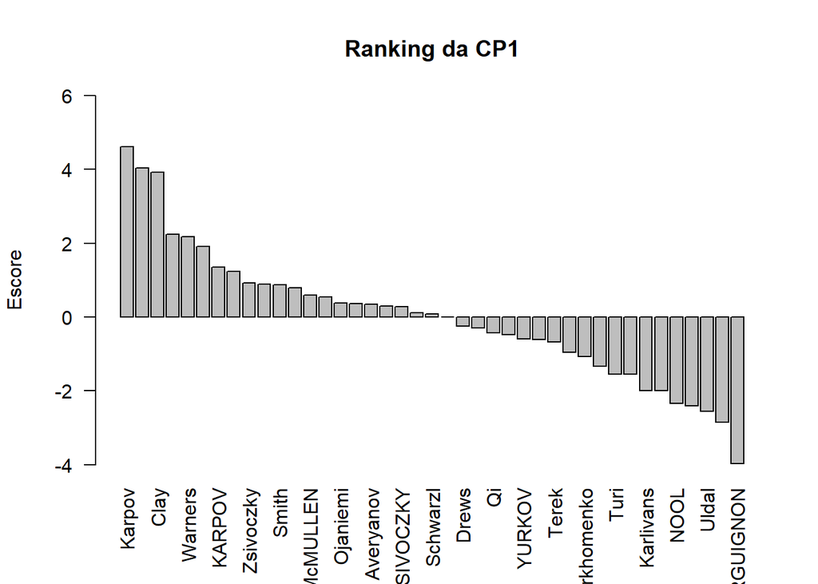

```r
barplot(ranking$Dim.1,
        ylim = c(-4,6),
        names.arg = ranking$name,
        main = "Ranking da CP1", ylab = "Escore",
        las = 2)
```

## Questão 10

Vetor de médias

```r
mu = c(95.52,164.38,55.69,93.39,17.98,31.13)
```

Matriz de covariâncias

```r
S = matrix(c(3266.46,1343.97,731.54,1175.50,162.68,238.37,
             1343.97,721.91,324.25,537.35,80.17,117.73,
             731.54,324.25,179.28,281.17,39.15,56.80,
             1175.50,537.35,281.17,474.98,63.73,94.85,
             162.68,80.17,39.15,63.73,9.95,13.88,
             238.37,117.73,56.80,94.85,13.88,21.26),byrow=T,nrow=6)
S
```

```
##         [,1]    [,2]   [,3]    [,4]   [,5]   [,6]
## [1,] 3266.46 1343.97 731.54 1175.50 162.68 238.37
## [2,] 1343.97  721.91 324.25  537.35  80.17 117.73
## [3,]  731.54  324.25 179.28  281.17  39.15  56.80
## [4,] 1175.50  537.35 281.17  474.98  63.73  94.85
## [5,]  162.68   80.17  39.15   63.73   9.95  13.88
## [6,]  238.37  117.73  56.80   94.85  13.88  21.26
```

### a) Componentes Principais a partir da matriz de covariâncias

Autovalores e autovetores da matriz de covariâncias

```r
auto = eigen(S)
autoval = matrix(auto$values,nrow=1)
autovet = auto$vectors

variaveis = c("X1","X2","X3","X4","X5","X6")
cps = c("CP1","CP2","CP3","CP4","CP5","CP6")

colnames(autoval) = cps
rownames(autovet) = variaveis
colnames(autovet) = cps
```

Componentes Principais

```r
autovet
```

```
##           CP1         CP2         CP3         CP4          CP5           CP6
## X1 0.84933911  0.47083174  0.22660616 -0.07426037  0.008692249  0.0002016017
## X2 0.36855162 -0.84607780  0.36813225 -0.01275430  0.110783709  0.0191050346
## X3 0.19413158 -0.05812709 -0.30314314  0.92838758  0.012288753  0.0705967427
## X4 0.31467769 -0.21674766 -0.84857608 -0.35506048  0.082353215 -0.0326656761
## X5 0.04391809 -0.06035442 -0.00181524  0.06016158 -0.440118616 -0.8928053752
## X6 0.06445825 -0.09202640 -0.03388032 -0.05226733 -0.887138069  0.4432635475
```

Porcentagens de variação das componentes

```r
perc = autoval/sum(autoval)*100
perc
```

```
##           CP1      CP2      CP3       CP4        CP5        CP6
## [1,] 95.82857 3.262118 0.691591 0.1736636 0.03245417 0.01160817
```

Porcentagens de variação acumuladas das componentes

```r
perc_acum = cumsum(perc)
perc_acum
```

```
## [1]  95.82857  99.09068  99.78227  99.95594  99.98839 100.00000
```

A primeira componente explica 95.83% da variância total amostral.

Matriz de correlações P

```r
# Encontrando a matriz V^(1/2)
sqrtV = diag(sqrt(diag(S)))

# Encontrando a matriz P
sqrtV.inv = solve(sqrtV)
P = sqrtV.inv %*% S %*% sqrtV.inv
P
```

```
##           [,1]      [,2]      [,3]      [,4]      [,5]      [,6]
## [1,] 1.0000000 0.8752042 0.9559463 0.9437268 0.9023686 0.9045473
## [2,] 0.8752042 1.0000000 0.9013066 0.9176521 0.9459296 0.9503071
## [3,] 0.9559463 0.9013066 1.0000000 0.9635303 0.9269457 0.9200274
## [4,] 0.9437268 0.9176521 0.9635303 1.0000000 0.9270320 0.9438827
## [5,] 0.9023686 0.9459296 0.9269457 0.9270320 1.0000000 0.9543250
## [6,] 0.9045473 0.9503071 0.9200274 0.9438827 0.9543250 1.0000000
```

Autovalores e autovetores da matriz de correlações

```r
auto = eigen(P)
autoval = matrix(auto$values,nrow=1)
autovet = auto$vectors

variaveis = c("X1","X2","X3","X4","X5","X6")
cps = c("CP1","CP2","CP3","CP4","CP5","CP6")

colnames(autoval) = cps
rownames(autovet) = variaveis
colnames(autovet) = cps
```

Componentes principais

```r
autovet
```

```
##          CP1        CP2         CP3         CP4         CP5         CP6
## X1 0.4036808 -0.5582767 -0.27967093 -0.28032483  0.59302281 -0.12998083
## X2 0.4043071  0.5322708  0.19620778 -0.71690884 -0.02365283 -0.01443543
## X3 0.4099516 -0.3892540 -0.03786472 -0.06175226 -0.56095345  0.60042081
## X4 0.4120022 -0.2229342  0.57599843  0.24375873 -0.23055114 -0.57983463
## X5 0.4091349  0.3190228 -0.70150968  0.28979996 -0.24028163 -0.31144503
## X6 0.4103415  0.3194073  0.24075490  0.51014118  0.47138798  0.43495431
```

Porcentagens de variação das componentes

```r
perc = autoval/sum(autoval)*100
perc
```

```
##           CP1      CP2       CP3       CP4       CP5       CP6
## [1,] 94.07619 2.929575 0.9419767 0.8206797 0.7889876 0.4425888
```

Porcentagens de variação acumuladas das componentes

```r
perc_acum = cumsum(perc)
perc_acum
```

```
## [1]  94.07619  97.00577  97.94774  98.76842  99.55741 100.00000
```

A primeira componente principal explica 94% da variância total dos dados.

### c) Similaridades e diferenças entre as análises

Os resultados foram similares para as duas análises. A primeira componente em cada uma delas representam quase que toda a variação total dos dados. As duas análises diferem um pouco quanto à segunda componente em diante, mas todas essas últimas explicam muito pouco a variância total da amostra.